# R Notebook

```r
boot_times<-10
```

```r
table(hints5$GeneralHealth_of) %>% cumsum / sum(!is.na(hints5$GeneralHealth_of))
```

```
Excellent Very good      Good      Fair      Poor
0.1164388 0.4774746 0.8349820 0.9737887 1.0000000
```

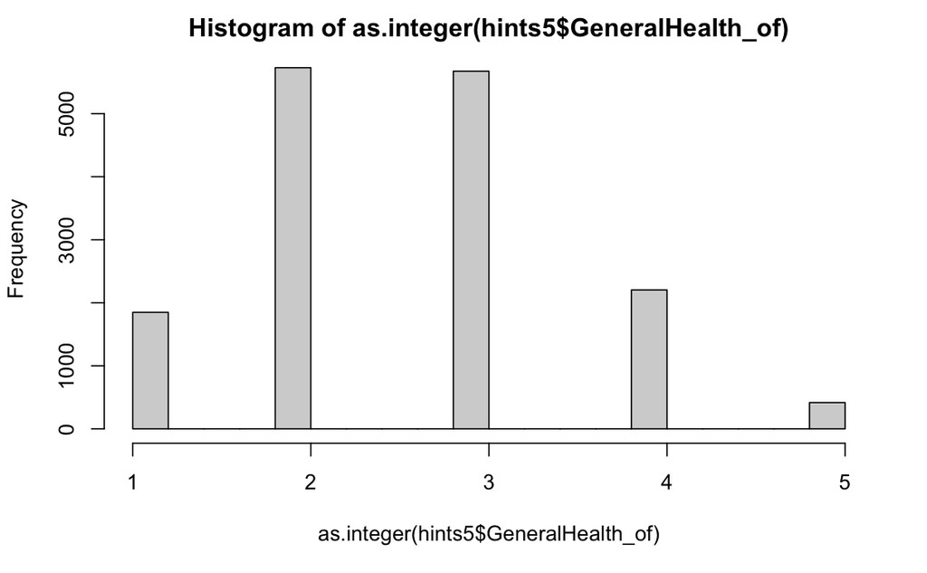

```r
hist(as.integer(hints5$GeneralHealth_of))
```

```r
library(magrittr)
library(dplyr)



data_dir <- "/Users/benjaminsmith/Dropbox (University of Oregon)/UO-SAN Lab/Berkman Lab/Devaluation/analysis_files/data/"

preprocessed_data_filepath <- paste0(data_dir,"cloudresearch_survey_results/orfcs_preprocessed2_anon_by_subj.csv")
library(readr)
library(ggplot2)
library(GGally)
orfcs_dataset <- readr::read_csv(preprocessed_data_filepath)
```

Let’s do our best to include all the same covariates we previously included.

# HINTS dataset: two mediators

This follows Hayes PROCESS Model 6 with two mediators but we are doing it here in Lavaan.

Variables are:

- Treatment: Rurality
- Two Mediators: household income, and fruit and vegetable consumption, in that order.
- Outcome: Physical and health measures. Altogether, we’ll repeat the mediation several times, with the following outcomes variables: BMI, self-rated health, aggregated cardiometabolic health, and high blood pressure. (and cancer??)

This model below is adapted from https://towardsdatascience.com/doing-and-reporting-a-serial-mediation-model-with-two-mediators-in-r-with-lavaan-739ed3155814

I think they’ve left some things out. I need to do a bit more research to work out how to properly implement this, probably including a basic crash course in SEM.

```r
library(stringi)
# [1] "Fruit_vegetables_z~HINTSIsRural_i+Age_c+I(Age_c^2)+RacePP+Gender3C+filename"
# [1] "MedConditions_HighBP_i~Fruit_vegetables_z+HINTSIsRural_i+Age_c+I(Age_c^2)+RacePP+Gender3C+filename"
# IncomeRanges_r

#need to do prepare variables so lavaan can process them
hints5_pp <- hints5
#add quadratic
hints5_pp$Age_c_pow2 <- hints5_pp$Age_c^2


#one-hot some variables
factor_to_clean_string <- function(data, col_to_stringify){
  data[[col_to_stringify]] <- as.character(data[[col_to_stringify]])
  data[[col_to_stringify]] <- (
    str_replace_all(data[[col_to_stringify]],"\\s","_") %>%
      str_replace_all("\\W","")
  )#table(hints5_pp[[col_to_stringify]])
  return(data)
}

hints5_pp<-factor_to_clean_string(hints5_pp,"RacePP2")
hints5_pp$RacePP2<-factor(hints5_pp$RacePP2)
hints5_pp <- mltools::one_hot(hints5_pp,"RacePP2",dropCols = FALSE)
print(paste0(colnames(hints5_pp)[grepl("RacePP2_",colnames(hints5_pp))],collapse=" + "))
```

```
[1] "RacePP2_American_Indian_or_Alaska_Native + RacePP2_Asian_Indian + RacePP2_Black + RacePP2_Chinese + RacePP2_Filipino + RacePP2_Japanese + RacePP2_Korean + RacePP2_Missing_Data + RacePP2_Multiple_races_selected + RacePP2_Other_Asian + RacePP2_Pacific_Islander + RacePP2_Vietnamese + RacePP2_White…
```

```r
hints5_pp<-factor_to_clean_string(hints5_pp,"Gender3C")
hints5_pp$Gender3C<-factor(hints5_pp$Gender3C)
hints5_pp <- mltools::one_hot(hints5_pp,"Gender3C",dropCols = FALSE)
print(paste0(colnames(hints5_pp)[grepl("Gender3C_",colnames(hints5_pp))],collapse=" + "))
```

```
[1] "Gender3C_Female + Gender3C_Male + Gender3C_MissingOrMultiple"
```

Now prepare the ORFCS dataset for lavaan.

```r
#need to do prepare variables so lavaan can process them
orfcs_dataset_pp <- data.table(orfcs_dataset)
#add quadratic
orfcs_dataset_pp$DEMO_Age_c_pow2 <- orfcs_dataset_pp$DEMO_Age_c^2


#one-hot some variables


orfcs_dataset_pp<-factor_to_clean_string(orfcs_dataset_pp,"RaceC2")
orfcs_dataset_pp$RaceC2<-factor(orfcs_dataset_pp$RaceC2)
orfcs_dataset_pp <- mltools::one_hot(orfcs_dataset_pp,"RaceC2",dropCols = FALSE)
print(paste0(colnames(orfcs_dataset_pp)[grepl("RaceC2_",colnames(orfcs_dataset_pp))],collapse=" + "))
```

```
[1] "RaceC2_Asian + RaceC2_HawaiianOtherPacificIslander + RaceC2_HispanicAnyRace + RaceC2_OtherRaceRaceNotReported + RaceC2_WhiteOnly"
```

```r
orfcs_dataset_pp<-factor_to_clean_string(orfcs_dataset_pp,"Gender3C")
orfcs_dataset_pp$Gender3C<-factor(orfcs_dataset_pp$Gender3C)
orfcs_dataset_pp <- mltools::one_hot(orfcs_dataset_pp,"Gender3C",dropCols = FALSE)
print(paste0(colnames(orfcs_dataset_pp)[grepl("Gender3C_",colnames(orfcs_dataset_pp))],collapse=" + "))
```

```
[1] "Gender3C_Female + Gender3C_Male + Gender3C_Other"
```

```r
#TREAT=HINTSIsRural_i
#m1=IncomeRanges_r
#m2=Fruit_vegetables_z
#OUTCOME=MedConditions_HighBP_i


#NEXT TO DO: DEAL WITH CATEGORICAL DATA. GUIDE HERE: https://lavaan.ugent.be/tutorial/cat.html
hints_model_template=
"
  #Regressions
  IncomeRanges_r ~ ab*HINTSIsRural_i + Age_c + Age_c_pow2 + Gender3C_Male + Gender3C_MissingOrMultiple + RacePP2_American_Indian_or_Alaska_Native + RacePP2_Asian_Indian + RacePP2_Black + RacePP2_Chinese + RacePP2_Filipino + RacePP2_Japanese + RacePP2_Korean + RacePP2_Missing_Data + RacePP2_Multiple_races_selected + RacePP2_Other_Asian + RacePP2_Pacific_Islander + RacePP2_Vietnamese

  Fruit_vegetables_z ~ bc*IncomeRanges_r + ac*HINTSIsRural_i + Age_c + Age_c_pow2 + Gender3C_Male + Gender3C_MissingOrMultiple + RacePP2_American_Indian_or_Alaska_Native + RacePP2_Asian_Indian + RacePP2_Black + RacePP2_Chinese + RacePP2_Filipino + RacePP2_Japanese + RacePP2_Korean + RacePP2_Missing_Data + RacePP2_Multiple_races_selected + RacePP2_Other_Asian + RacePP2_Pacific_Islander + RacePP2_Vietnamese

  (OUTCOMEVAR) ~ cd*Fruit_vegetables_z + bd*IncomeRanges_r + ad*HINTSIsRural_i + Age_c + Age_c_pow2 + Gender3C_Male + Gender3C_MissingOrMultiple + RacePP2_American_Indian_or_Alaska_Native + RacePP2_Asian_Indian + RacePP2_Black + RacePP2_Chinese + RacePP2_Filipino + RacePP2_Japanese + RacePP2_Korean + RacePP2_Missing_Data + RacePP2_Multiple_races_selected + RacePP2_Other_Asian + RacePP2_Pacific_Islander + RacePP2_Vietnamese


  #Defined Parameters:
  indirect_effect := ab*bc*cd
  effect_via_inc_only :=ab*bd
  effect_via_fruit_vege_only :=ac*cd
  direct_effect := ad
"

# - Outcome: Physical and health measures. Altogether, we'll repeat the mediation several times, with the following outcomes variables: BMI, self-rated health, aggregated cardiometabolic health, and high blood pressure.

outcome_measures <- c(
  "BMI",
  "GeneralHealth_i",
  "MedConditionsAggregate",
  "MedConditions_HighBP_i",
  "EverHadCancer_i"#no cancer for now, doesn't seem very important.
  )
```

# Oregon dataset: three mediators

For comparison with HINTS, we’ll first repeat the HINTS dataset two-mediator model as described above, but using three mediators.

THen, we’ll proceed with our main Oregon dataset analysis.

This follows Hayes PROCESS Model 6 with THREE mediators but we are doing it here in Lavaan.

Variables are:

```r
#TREAT=HINTSIsRural_i
#m1=IncomeRanges_r
#m2=Fruit_vegetables_z
#OUTCOME=MedConditions_HighBP_i


# mb <- lm(MESA_healthyfoodavailability_z~RuralZIP_i+Gender3C+DEMO_Age_c+RaceC2+PSS_z,data_to_measure)
# mc <- lm(BMI~RuralZIP_i+Gender3C+DEMO_Age_c+RaceC2+MESA_healthyfoodavailability_z+PSS_z,data_to_measure)

# [1] "RaceC2_Asian + RaceC2_HawaiianOtherPacificIslander + RaceC2_HispanicAnyRace + RaceC2_OtherRaceRaceNotReported + RaceC2_WhiteOnly"
# [1] "Gender3C_Female + Gender3C_Male + Gender3C_Other"

#NEXT TO DO: DEAL WITH CATEGORICAL DATA. GUIDE HERE: https://lavaan.ugent.be/tutorial/cat.html
oregon_model_template=
"
  #Regressions
  aSES_02_z ~ ab*RuralZIP_i + DEMO_Age_c + DEMO_Age_c_pow2 + Gender3C_Male + Gender3C_Other + RaceC2_Asian + RaceC2_HawaiianOtherPacificIslander + RaceC2_HispanicAnyRace + RaceC2_OtherRaceRaceNotReported

  MESA_healthyfoodavailability_z ~ bc*aSES_02_z + ac*RuralZIP_i + DEMO_Age_c + DEMO_Age_c_pow2 + Gender3C_Male + Gender3C_Other + RaceC2_Asian + RaceC2_HawaiianOtherPacificIslander + RaceC2_HispanicAnyRace + RaceC2_OtherRaceRaceNotReported

  FFQ_fruit_vegetables_z ~ cd*MESA_healthyfoodavailability_z + bd*aSES_02_z + ad*RuralZIP_i + DEMO_Age_c + DEMO_Age_c_pow2 + Gender3C_Male + Gender3C_Other + RaceC2_Asian + RaceC2_HawaiianOtherPacificIslander + RaceC2_HispanicAnyRace + RaceC2_OtherRaceRaceNotReported

  (OUTCOMEVAR) ~ de*FFQ_fruit_vegetables_z + ce*MESA_healthyfoodavailability_z + be*aSES_02_z + ae*RuralZIP_i + DEMO_Age_c + DEMO_Age_c_pow2 + Gender3C_Male + Gender3C_Other + RaceC2_Asian + RaceC2_HawaiianOtherPacificIslander + RaceC2_HispanicAnyRace + RaceC2_OtherRaceRaceNotReported


  #Defined Parameters:
  indirect_effect := ab*bc*cd*de
  d_rural_food_availability := ac
  id_rural_food_availability := ab*bc
  rural_inc_consump := ab*bd*de
  direct_effect := ae
"

# - Outcome: Physical and health measures. Altogether, we'll repeat the mediation several times, with the following outcomes variables: BMI, self-rated health, aggregated cardiometabolic health, and high blood pressure.

outcome_measures <- c(
  "BMI"#,
  #"GeneralHealth_i",
  #"MedConditionsAggregate",
  #"MedConditions_HighBP_i",
  #"EverHadCancer_i"#no cancer for now, doesn't seem very important.
  )
```

# Hybrid: three mediators

This follows Hayes PROCESS Model 6 with THREE mediators. We need to somehow manually combine the two datasets by multiplying effects. Need to follow bootstrap analysis, which means we need to extract raw bootstrap results and combine them. I’m not sure it’s feasible, but it would be quite valuable to do.

Is there a way to run the bootstrap and then extract the results over the bootstrap??

```r
for (outcome_var in outcome_measures){
  set.seed(05711846)
  hints_model_w_outcome <- str_replace_all(hints_model_template,"\\(OUTCOMEVAR\\)",outcome_var)
  cat(paste0("MEDIATION MODEL FOR OUTCOME: ",outcome_var))
  cat(hints_model_w_outcome)
  fit=sem(
    hints_model_w_outcome,
    hints5_pp,
    se = "bootstrap",
    bootstrap=boot_times,
    likelihood = "wishart")

  print(summary(fit))
  cat("-----\n\n\n")
}
```

```
MEDIATION MODEL FOR OUTCOME: BMI
  #Regressions
  IncomeRanges_r ~ ab*HINTSIsRural_i + Age_c + Age_c_pow2 + Gender3C_Male + Gender3C_MissingOrMultiple + RacePP2_American_Indian_or_Alaska_Native + RacePP2_Asian_Indian + RacePP2_Black + RacePP2_Chinese + RacePP2_Filipino + RacePP2_Japanese + RacePP2_Korean + RacePP2_Missing_Data + RacePP2_Multiple_…

  Fruit_vegetables_z ~ bc*IncomeRanges_r + ac*HINTSIsRural_i + Age_c + Age_c_pow2 + Gender3C_Male + Gender3C_MissingOrMultiple + RacePP2_American_Indian_or_Alaska_Native + RacePP2_Asian_Indian + RacePP2_Black + RacePP2_Chinese + RacePP2_Filipino + RacePP2_Japanese + RacePP2_Korean + RacePP2_Missing_…

  BMI ~ cd*Fruit_vegetables_z + bd*IncomeRanges_r + ad*HINTSIsRural_i + Age_c + Age_c_pow2 + Gender3C_Male + Gender3C_MissingOrMultiple + RacePP2_American_Indian_or_Alaska_Native + RacePP2_Asian_Indian + RacePP2_Black + RacePP2_Chinese + RacePP2_Filipino + RacePP2_Japanese + RacePP2_Korean + RacePP2…


  #Defined Parameters:
  indirect_effect := ab*bc*cd
  effect_via_inc_only :=ab*bd
  effect_via_fruit_vege_only :=ac*cd
  direct_effect := ad
```

```
lavaan WARNING:
    The variance-covariance matrix of the estimated parameters (vcov)
    does not appear to be positive definite! The smallest eigenvalue
    (= -7.548568e-16) is smaller than zero. This may be a symptom that
    the model is not identified.
```

```
lavaan 0.6-11 ended normally after 1 iterations

  Estimator                                         ML
  Optimization method                           NLMINB
  Number of model parameters                        57

                                                  Used       Total
  Number of observations                          6231       16092

Model Test User Model:

  Test statistic                                 0.000
  Degrees of freedom                                 0

Parameter Estimates:

  Standard errors                            Bootstrap
  Number of requested bootstrap draws               10
  Number of successful bootstrap draws              10

Regressions:
                       Estimate    Std.Err  z-value  P(>|z|)
  IncomeRanges_r ~
    HINTSIsR_ (ab)         -0.717    0.060  -11.991    0.000
    Age_c                   0.012    0.003    4.396    0.000
    Age_c_pw2              -0.001    0.000  -13.171    0.000
    Gndr3C_Ml               0.461    0.071    6.534    0.000
    Gnd3C_MOM              -0.805    0.126   -6.410    0.000
    RPP2_A_I_              -1.234    0.340   -3.628    0.000
    RcPP2_A_I               0.626    0.193    3.237    0.001
    RcPP2_Blc              -1.433    0.071  -20.039    0.000
    RcPP2_Chn               0.065    0.254    0.257    0.797
    RcPP2_Flp               0.182    0.198    0.918    0.358
    RcPP2_Jpn               0.873    0.233    3.742    0.000
    RcPP2_Krn               0.210    0.414    0.508    0.611
    RcPP2_M_D              -1.153    0.126   -9.122    0.000
    RcPP2_M__              -0.914    0.080  -11.381    0.000
    RcPP2_O_A              -0.568    0.298   -1.903    0.057
    RcPP2_P_I              -2.205    0.361   -6.103    0.000
    RcPP2_Vtn               0.281    0.186    1.511    0.131
```

[output cut: 266 more lines]

[output not shown]

```r
dim(fit@boot$coef)
```

```
[1] 10 57
```

```r
fit_summary<-summary(fit)
```

```
lavaan 0.6-11 ended normally after 1 iterations

  Estimator                                         ML
  Optimization method                           NLMINB
  Number of model parameters                        57

                                                  Used       Total
  Number of observations                          6231       16092

Model Test User Model:

  Test statistic                                 0.000
  Degrees of freedom                                 0

Parameter Estimates:

  Standard errors                            Bootstrap
  Number of requested bootstrap draws               10
  Number of successful bootstrap draws              10

Regressions:
                       Estimate    Std.Err  z-value  P(>|z|)
  IncomeRanges_r ~
    HINTSIsR_ (ab)         -0.717    0.060  -11.991    0.000
    Age_c                   0.012    0.003    4.396    0.000
    Age_c_pw2              -0.001    0.000  -13.171    0.000
    Gndr3C_Ml               0.461    0.071    6.534    0.000
    Gnd3C_MOM              -0.805    0.126   -6.410    0.000
    RPP2_A_I_              -1.234    0.340   -3.628    0.000
    RcPP2_A_I               0.626    0.193    3.237    0.001
    RcPP2_Blc              -1.433    0.071  -20.039    0.000
    RcPP2_Chn               0.065    0.254    0.257    0.797
    RcPP2_Flp               0.182    0.198    0.918    0.358
    RcPP2_Jpn               0.873    0.233    3.742    0.000
    RcPP2_Krn               0.210    0.414    0.508    0.611
    RcPP2_M_D              -1.153    0.126   -9.122    0.000
    RcPP2_M__              -0.914    0.080  -11.381    0.000
    RcPP2_O_A              -0.568    0.298   -1.903    0.057
    RcPP2_P_I              -2.205    0.361   -6.103    0.000
    RcPP2_Vtn               0.281    0.186    1.511    0.131
```

[output cut: 37 more lines]

```
    RcPP2_P_I               0.485    0.994    0.488    0.625
    RcPP2_Vtn              -5.673    0.621   -9.132    0.000

Variances:
                   Estimate    Std.Err  z-value  P(>|z|)
   .IncomeRanges_r      4.410    0.061   71.703    0.000
   .Fruit_vgtbls_z      0.942    0.016   59.993    0.000
   .BMI                38.979    1.137   34.276    0.000

Defined Parameters:
                   Estimate    Std.Err  z-value  P(>|z|)
    indirect_effct      0.036    0.006    6.329    0.000
    effct_v_nc_nly      0.211    0.031    6.788    0.000
    effct_v_frt_v_      0.038    0.024    1.546    0.122
    direct_effect       0.919    0.252    3.645    0.000
```

So how do these all correspond to the mere 57 items we found in the bootstrap?

nope. how about just looking at the summary object?

```r
fit_summary$PE[1:57,1:4]
```

|  | lhs | op | rhs | label |
| --- | --- | --- | --- | --- |
| 1 | IncomeRanges_r | ~ | HINTSIsRural_i | ab |
| 2 | IncomeRanges_r | ~ | Age_c |  |
| 3 | IncomeRanges_r | ~ | Age_c_pow2 |  |
| 4 | IncomeRanges_r | ~ | Gender3C_Male |  |
| 5 | IncomeRanges_r | ~ | Gender3C_MissingOrMultiple |  |
| 6 | IncomeRanges_r | ~ | RacePP2_American_Indian_or_Alaska_Native |  |
| 7 | IncomeRanges_r | ~ | RacePP2_Asian_Indian |  |
| 8 | IncomeRanges_r | ~ | RacePP2_Black |  |
| 9 | IncomeRanges_r | ~ | RacePP2_Chinese |  |
| 10 | IncomeRanges_r | ~ | RacePP2_Filipino |  |

[output cut: 47 more lines]

OK great. So we use this latter table to tell us which items from the bootstrap to use. Then we can query the coef table in the bootstrap, which has `boot_times` measures for every item.

Then we can run estimations for each item in the model SEPARATELY for HINTS and ORFCS, then manually combine them. Should replicate the within-sample analysis with my code before implementing.

```r
dim(fit@boot$coef)
```

```
[1] 10 57
```